# 1.3 Действия с приближенными числами

**Абсолютная погрешность алгеброической суммы** ($\Delta_{a\pm b}$) нескольких приближенных чисел ($a$ и $b$) не превышаетсуммы абсолютных погрешностей этих чисел ($\Delta_a + \Delta_b$ ). $$\Delta_{a\pm b}\leq\Delta_a + \Delta_b$$

### Правило сложения и вычитания приближенных чисел:

- Шаг первый: Выделить наименее точное число (или числа), то есть такое, в десятичной записи которого наименьшее число верных десятичных знаков;
- Шаг второй: Округлить остальные числа так, чтобы каждое из них содержало на один (запасной) знак больше, чем выделенное число;
- Шаг третий: Выполнить сложение и вычитание с учетом сохраненных знаков;
- Шаг четвертый: Полученный результат округлить до предпоследнего знака.
  - Правила округления числа
  - А) Если первая из отбрасываемых цифр меньше 5, то сохраняемые десятичные знаки остаются без изменения.
  - Б) Если первая из отбрасываемых цифр больше 5, то последний из сохраняемых знаков увеличивают на 1.
  - В) Если первая из отбрасываемых цифр равна 5, а среди следующих за ней цифр есть отличные от нуля, то последний из сохраняемых знаков увеличивают на 1
  - Г) Если первая из отбрасываемых цифр равна 5, а все последующие - нули, то последний из сохраняемых десятичных знаков увеличивают на 1, когда он нечетен, и сохраняют неизменным, когда он четен (правило четной цифры).

### Теперь даваяте попробуем сложить числа.

$a=414.8$ ; $b=0.025$ ; $c=24.17$ ; $d=0.000326$ ; Наименее точное слагаемое можно определить либо через относительную погрешность, либо по минимальному колличеству значащих знаков после запятой... Округлим согластно правилу опираяся на количество знаков наименее точного числа. $a\to414.8$ ; $b\to0.02$ ; $c\to24.17$ ; $d\to0.00$ ; Теперь сложим округленные числа. $414.8 + 0.02 + 24.17 + 0.00 = 438.99 \to 439.0$

**Относительная погрешность произведения (частного)** ($\delta_{\frac{ab}c}$) приближенных чисел не превышает суммы относительных погрешностей этих чисел ($\delta_a+\delta_b+\delta_c$). $$\delta_{\frac{ab}c}\leq\delta_a+\delta_b+\delta_c$$

- Шаг первый: из всех чисел, которые предстоит умножать и делить, выделить наименее точное - то, в котором меньше всего верных значащих цифр;
- Шаг второй: *округлить* остальные числа так, чтобы каждое из них содержало на одну (запасную) значащую цифру больше, чем выделенное число;
- Шаг третий: выполнить умножение и деление округленных чисел с учетом сохраненных значащих цифр;
- Шаг четвертый: оставить в ответе столько значащих цифр, сколько их было в наименее точном числе.

### Теперь даваяте попробуем "произвести"(перемножить, это шутка) числа.

$a=3.5$; $b=83.368$; Все цифры верные. Наименее точное число из них $a$.  
Округлим по алгоритму по $a$: $a=3.5\to3.5$; $b=83.368\to83.4$;  
Перемножим: $ab=3.5*83.4=291,9 \approx 2.9*10^2$; Здесь $\approx$ и $\to$ - приблеженное значение и округление соответственно.

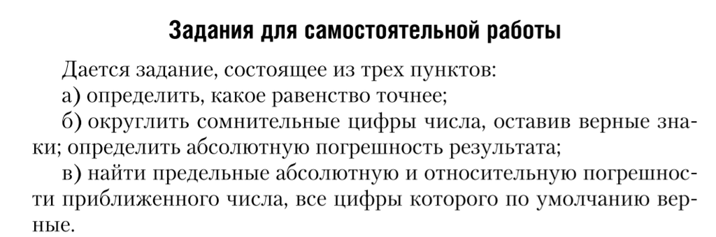

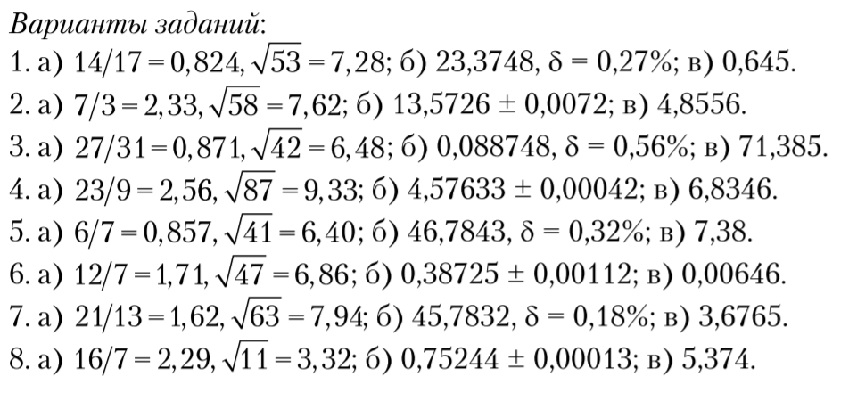

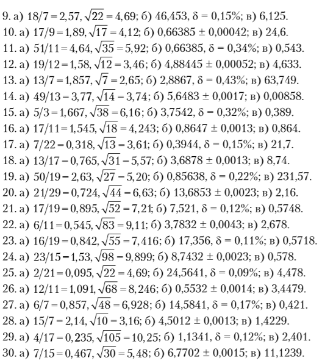

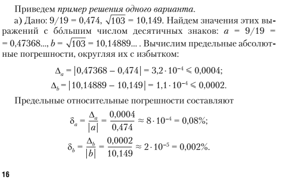

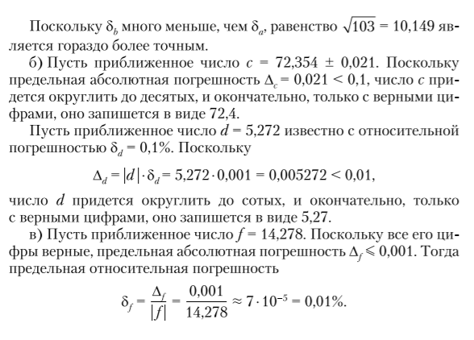